# Econ 144 Project 3

Daniel Wang, Tiffany Mok, Mike Cai, Jiyoon Kim

2024-06-06

# Intro

The dataset for this project comprises quarterly arrivals from the United States to Australia, denoted as us_arrivals, from 1981 Q1 to 2012 Q3. This data is derived from the broader aus_arrivals dataset in the fpp3 library, filtered specifically for entries where the origin is the United States. The dataset provides a temporal view of the number of visitors from the US to Australia, offering insights into travel trends, seasonal patterns, and potential impacts of external factors such as economic conditions, policy changes, and global events.

Tourism is a significant economic sector for Australia, contributing substantially to its GDP. Understanding and forecasting the flow of international visitors, particularly from major source countries like the United States, is crucial for stakeholders in the tourism industry, including government agencies, airlines, hotels, and tour operators. Accurate forecasts enable better resource allocation, marketing strategies, and policy-making to enhance the tourist experience and manage the economic impact.

The primary objective of this project is to develop robust forecasting models to predict future quarterly arrivals from the United States to Australia. By leveraging various time series forecasting techniques, we aim to identify the model that best captures the underlying patterns and provides the most accurate forecasts.

# Overview of Data

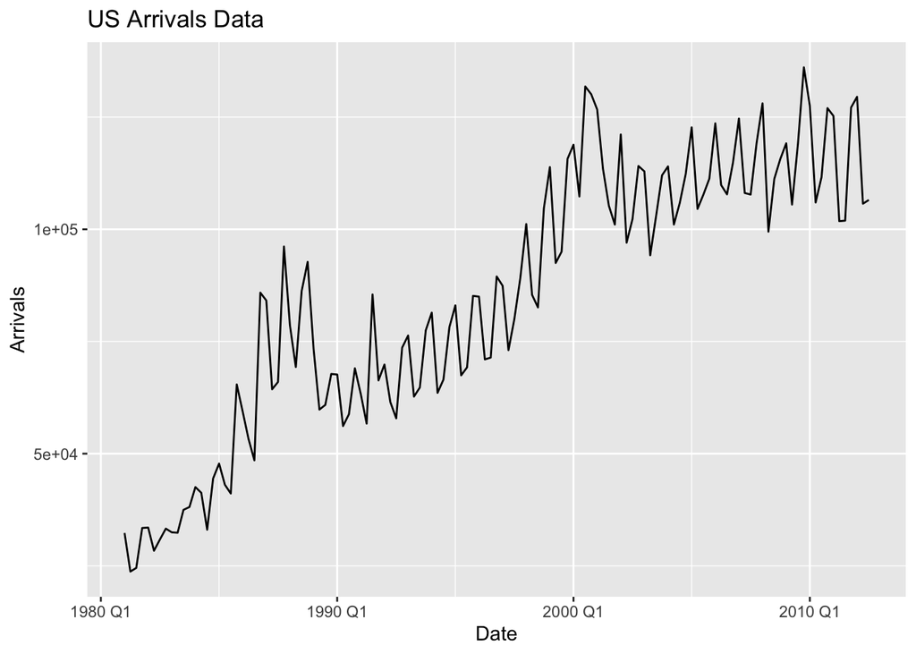

```r
# filter data to specify arrivals from the US
us_arrivals <- aus_arrivals |>
    dplyr::filter(Origin == "US")

# plot the data
autoplot(us_arrivals, .vars = Arrivals) + ggtitle("US Arrivals Data") + xlab("Date") +
    ylab("Arrivals")
```

```r
summary(us_arrivals$Arrivals)
```

```
##    Min. 1st Qu.  Median    Mean 3rd Qu.    Max.
##   23721   63950   85878   84849  108977  136094
```

The data shows an increasing amount of arrivals from the US to Australia over time. The summary shows that the mean number of arrivals was 84849, with the minimum at 23721 and maximum at 136094.

# ARIMA Model

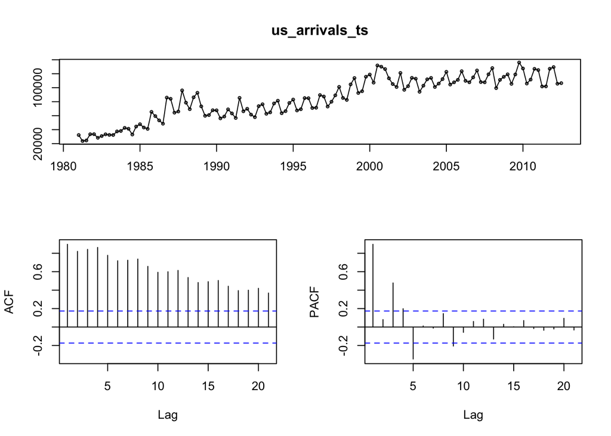

```r
# convert data to time series
us_arrivals_ts <- ts(us_arrivals$Arrivals, start = c(1981, 1), frequency = 4)

# create train/test split (for forecasts)
train <- window(us_arrivals_ts, end = c(2005, 4))
test <- window(us_arrivals_ts, start = c(2006, 1))

# plot tsdisplay
tsdisplay(us_arrivals_ts)
```

It seems like the data might not be stationary, so we might need to do some differencing. For the ACF plot, values are generally decreasing over time. For the PACF plot, there are significant spikes up to lag 5. Because of this, we will start by testing out an AR(5) model.

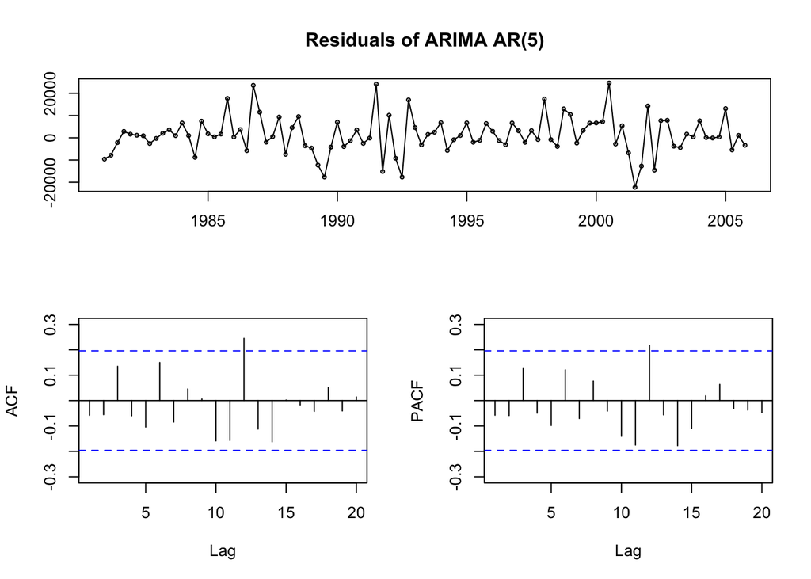

```r
# arima model 1
arima.model1 <- arima(train, order = c(5, 0, 0))
arima.resid1 <- resid(arima.model1)
tsdisplay(arima.resid1, main = "Residuals of ARIMA AR(5)")
```

```r
Box.test(arima.resid1, type = "Ljung-Box")
```

```
##
##  Box-Ljung test
##
## data:  arima.resid1
## X-squared = 0.34328, df = 1, p-value = 0.5579
```

For the most part, there are no significant spikes in the ACF/PACF plots. Based on the Box-Ljung results for arima model 1, we can conclude that there is no autocorrelation in the residuals. This suggests that the arima model sufficiently captures the autocorrelation present in the data.

Next, we will try to improve the model by differencing the data.

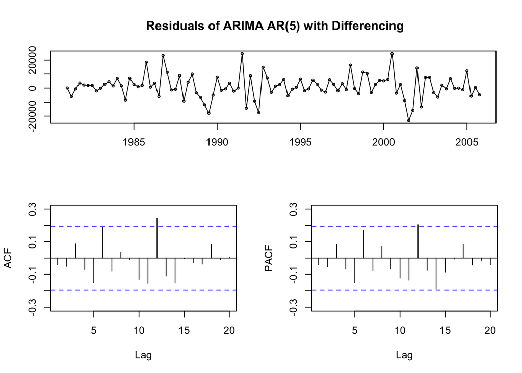

```r
# arima model 2
arima.model2 <- arima(train, order = c(5, 1, 0))
arima.resid2 <- resid(arima.model2)
tsdisplay(arima.resid2, main = " Residuals of ARIMA AR(5) with Differencing")
```

```r
Box.test(arima.resid2, type = "Ljung-Box")
```

```
##
##  Box-Ljung test
##
## data:  arima.resid2
## X-squared = 0.16695, df = 1, p-value = 0.6828
```

Again, there are barely any significant spikes in the ACF/PACF plots. Based on the Box-Ljung results, we can conclude that there is no autocorrelation in the residuals and that the arima model sufficiently captures autocorrelation in the data.